# NHANES Health Equity Classroom Dashboard

Descriptive, unweighted mean BMI by income group across NHANES cycles. For classroom learning; not for population inference.

## Audience Question

Audience: a public-health analyst preparing a short briefing on descriptive BMI patterns in the classroom NHANES equity dataset.

Question: among adults age 20-80, how does mean BMI vary across NHANES cycles for one selected income group?

## Setup

```r
library(tidyverse)  # AI-EDIT(2026-06-23): tidyverse-default — consolidated core library() calls into library(tidyverse)
library(knitr)

candidate_paths <- c(
  "examples/nhanes-equity/data/nhanes_equity_v6.csv",
  "../../examples/nhanes-equity/data/nhanes_equity_v6.csv"
)

data_path <- candidate_paths[file.exists(candidate_paths)][1]
if (is.na(data_path)) {
  stop("Could not find examples/nhanes-equity/data/nhanes_equity_v6.csv")
}

nhanes <- read_csv(data_path, show_col_types = FALSE)
```

## Control

This dashboard uses adults age 20-80. To see a different income group, change the value and re-render.

```r
available_income_groups <- sort(unique(na.omit(nhanes$IncomeGroup)))
selected_income <- "High Income (>3.5)"

if (!selected_income %in% available_income_groups) {
  selected_income <- available_income_groups[1]
}

selected_income
```

```
[1] "High Income (>3.5)"
```

## Summary

```r
dashboard_summary <- nhanes |>
  filter(
    Age >= 20,
    Age <= 80,
    IncomeGroup == selected_income,
    !is.na(BMI),
    !is.na(Cycle)
  ) |>
  group_by(Cycle) |>
  summarise(
    n = n(),
    mean_bmi = round(mean(BMI), 1),
    .groups = "drop"
  )

kable(dashboard_summary)
```

| Cycle | n | mean_bmi |
| --- | --- | --- |
| 1999-2000 | 1123 | 27.9 |
| 2001-2002 | 1491 | 28.1 |
| 2003-2004 | 1284 | 28.4 |
| 2005-2006 | 1480 | 28.5 |
| 2007-2008 | 1554 | 28.8 |
| 2009-2010 | 1562 | 28.7 |
| 2011-2012 | 1448 | 28.1 |
| 2013-2014 | 1586 | 28.3 |
| 2015-2016 | 1355 | 28.9 |
| 2017-2018 | 1359 | 29.0 |
| 2021-2023 | 2088 | 29.2 |

## Visualization

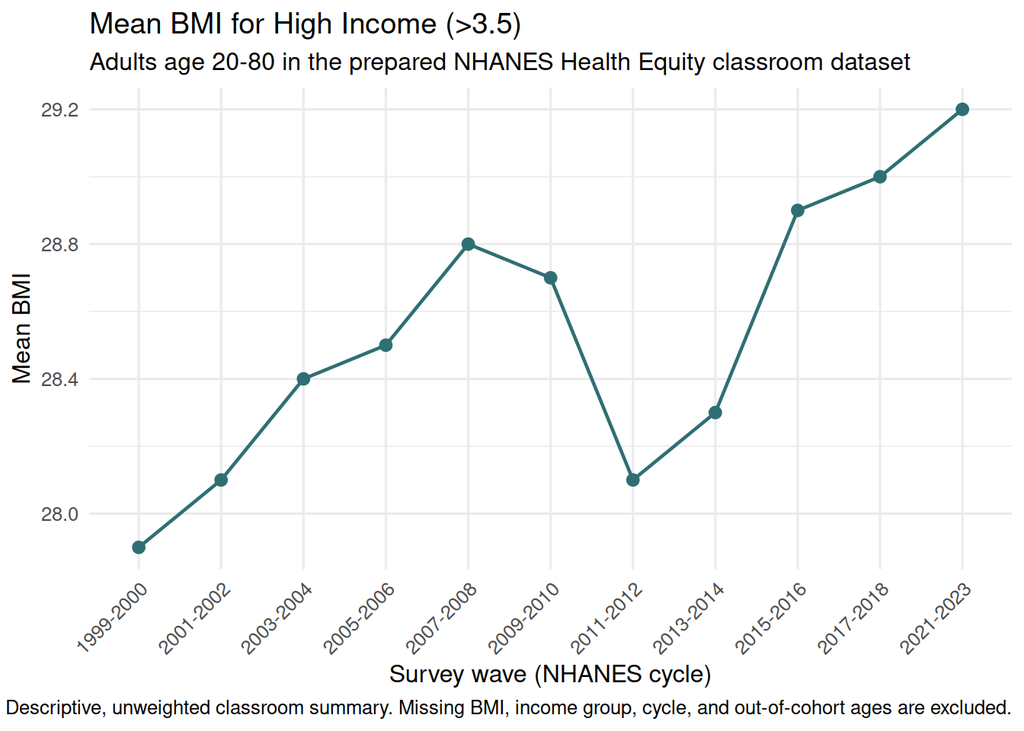

```r
ggplot(dashboard_summary, aes(x = Cycle, y = mean_bmi, group = 1)) +
  geom_line(linewidth = 0.8, color = "#2f6f73") +
  geom_point(size = 2.4, color = "#2f6f73") +
  labs(
    title = paste("Mean BMI for", selected_income),
    subtitle = "Adults age 20-80 in the prepared NHANES Health Equity classroom dataset",
    x = "Survey wave (NHANES cycle)",
    y = "Mean BMI",
    caption = "Descriptive, unweighted classroom summary. Missing BMI, income group, cycle, and out-of-cohort ages are excluded."
  ) +
  theme_minimal(base_size = 12) +
  theme(axis.text.x = element_text(angle = 45, hjust = 1))
```

## Interpretation

For the selected income group, the table and figure describe the mean BMI pattern across available NHANES cycles in the prepared classroom dataset. The dashboard should help the audience ask better questions about pattern, timing, and context rather than treat the line as a causal explanation.

## Limitation

This dataset is unweighted and descriptive. It does not account for NHANES survey design, does not estimate national prevalence, and should not be used to make causal claims about income and BMI.

## Privacy-Safe Publishing

- Use aggregate summaries, not row-level records.
- Avoid small-cell interpretations when `n` is low.
- State that outputs are descriptive and unweighted.
- Keep cached classroom data separate from any raw NHANES retrieval workflow.
- Do not upload row-level data to external AI tools.

## Where this goes next

Use the Week 8 course guidance to confirm that your change is audience-facing text rather than new analytic logic, then complete the required test and privacy notes.